# Презентация по лабораторной работе №6

Основы информационной безопасности

Осман АлиНиколай

1032239330@rudn.ru

Российский университет дружбы народов

2026-04-30

# Информация

## Докладчик

Осман АлиНиколай

студент

Российского университета дружбы народов им. П. Лумумбы

1032239330@rudn.ru

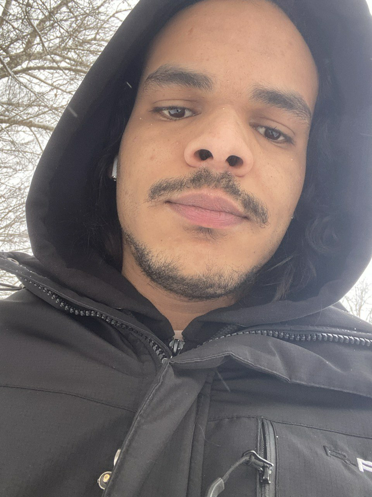

## Цель

Развить навыки администрирования ОС Linux. Получить первое практическое знакомство с технологией SELinux1. Проверить работу SELinx на практике совместно с веб-сервером Apache.

# Выполнение лабораторной работы

## Выполнение лабораторной работы

SELinux работает в режиме enforcing политики targeted с помощью команд getenforce и sestatus

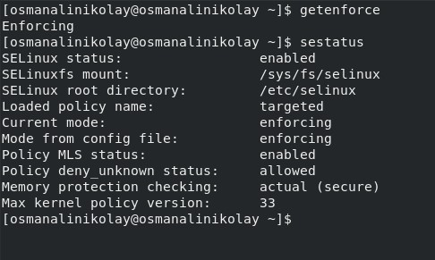

проверка режима работы SELinux

## Выполнение лабораторной работы

Запускаю сервер apache, далее обращаюсь с помощью браузера к веб-серверу, запущенному на компьютере, он работает, что видно из вывода команды `service httpd status`

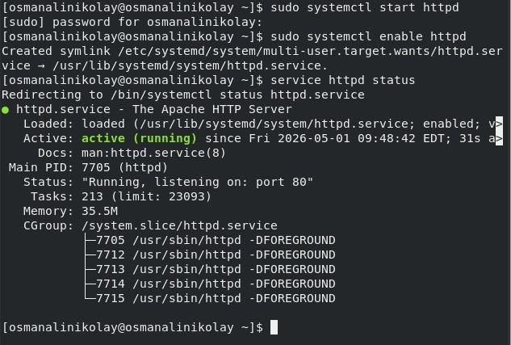

Проверка работы Apache

## Выполнение лабораторной работы

С помощью команды `ps auxZ | grep httpd` нашла веб-сервер Apache в списке процессов. Его контекст безопасности - httpd_t

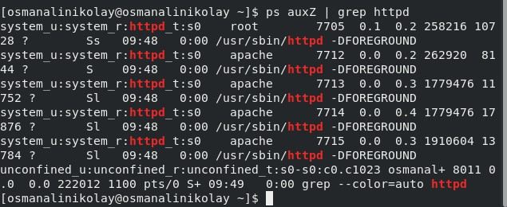

Контекст безопасности Apache

## Выполнение лабораторной работы

Просмотрела текущее состояние переключателей SELinux для Apache с помощью команды `sestatus -bigrep httpd`

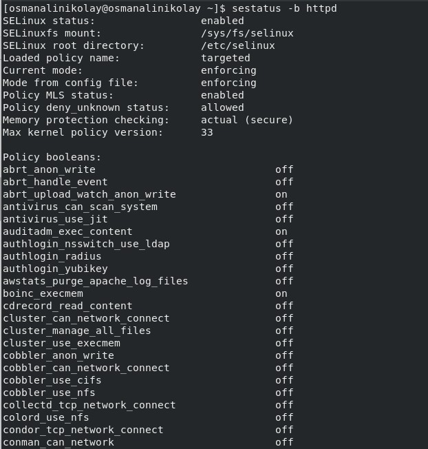

Состояние переключателей SELinux

## Выполнение лабораторной работы

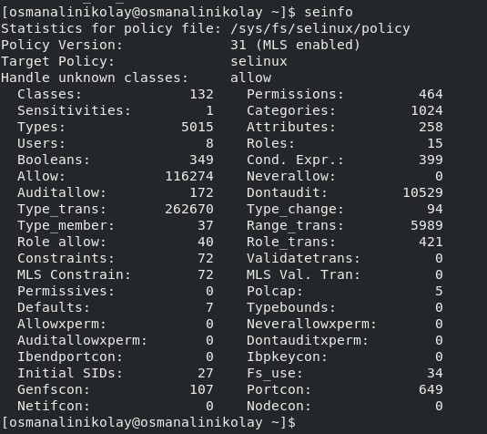

Cтатистика по политике

## Выполнение лабораторной работы

Типы поддиректорий, находящихся в директории `/var/www`, с помощью команды `ls -lZ /var/www` следующие: владелец - root, права на изменения только у владельца. Файлов в директории нет

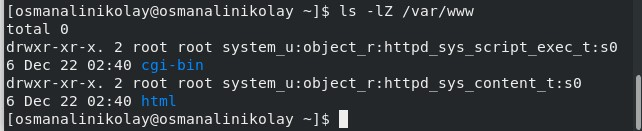

Типы поддиректорий

## Выполнение лабораторной работы

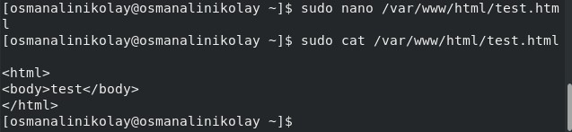

Создание файла

## Выполнение лабораторной работы

Проверяю контекст созданного файла. По умолчанию это httpd_sys_content_t

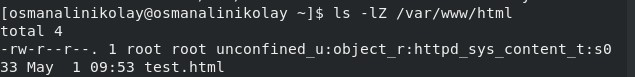

Контекст файла

## Выполнение лабораторной работы

Обращаюсь к файлу через веб-сервер, введя в браузере адрес http://127.0.0.1/test.html. Файл был успешно отображён

[figure not shown]

Отображение файла

## Выполнение лабораторной работы

Изменяю контекст файла `/var/www/html/test.html` с `httpd_sys_content_t` на любой другой, к которому процесс httpd не должен иметь доступа, например, `на samba_share_t`: `chcon -t samba_share_t /var/www/html/test.html` `ls -Z /var/www/html/test.html` Контекст действительно поменялся

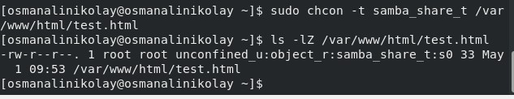

Изменение контекста

## Выполнение лабораторной работы

При попытке отображения файла в браузере получаем сообщение об ошибке файл не был отображён, хотя права доступа позволяют читать этот файл любому пользователю, потому что установлен контекст, к которому процесс httpd не должен иметь доступа.

[figure not shown]

Отображение файла

## Выполнение лабораторной работы

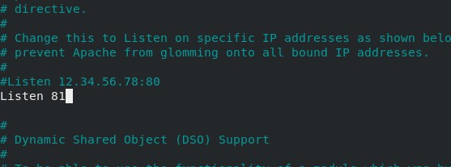

Изменение порта

## Выполнение лабораторной работы

Выполняю перезапуск веб-сервера Apache. Произошёл сбой

[figure not shown]

Попытка прослушивания другого порта

## Выполнение лабораторной работы

Просмотрите файлы `/var/log/http/error_log`, `/var/log/http/access_log` и `/var/log/audit/audit.log` и выясните, в каких файлах появились записи. Запись появилась в файлу error_log

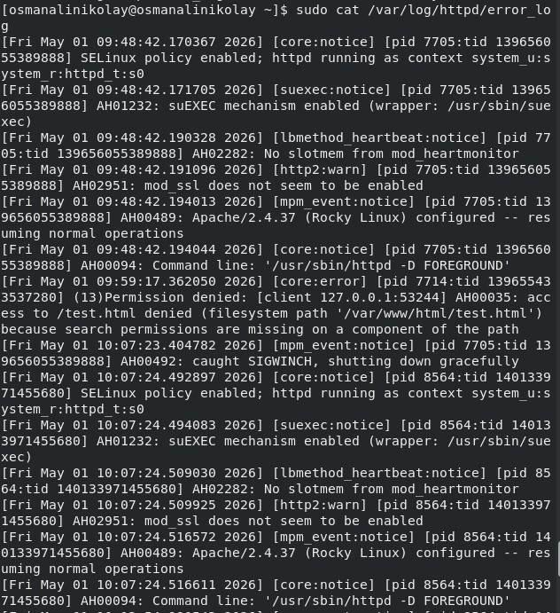

Проверка лог-файлов

## Выполнение лабораторной работы

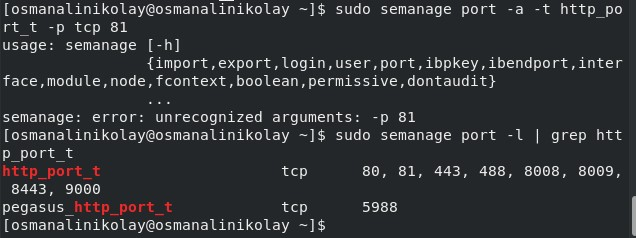

Проверка портов

## Выполнение лабораторной работы

Перезапускаю сервер Apache

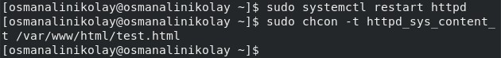

Перезапуск сервера

## Выполнение лабораторной работы

[figure not shown]

Проверка сервера

## Выполнение лабораторной работы

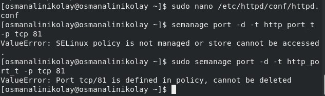

Проверка порта 81

## Выполнение лабораторной работы

Далее удаляю файл test.html, проверяю, что он удален

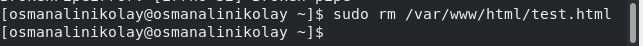

Удаление файла

## Вывод

В ходе выполнения данной лабораторной работы были развиты навыки администрирования ОС Linux, получено первое практическое знакомство с технологией SELinux и проверена работа SELinux на практике совместно с веб-сервером Apache.

:::